# Machine Learning and Well-Doing Fitness predictions

FroggyZ

Sunday, April 26, 2015

### Summary

This project uses fitness data and a machine learning algorith which aim is to predict how well people are doing their exercise. The data file comes from the **“Weight Lifting Exercises Dataset”** (http://groupware.les.inf.puc-rio.br/har).

### Data sets and Data Cleaning

#### Acquiring Data:

For the training and testing data set we note respectively 19622 and 20 observations (rows), and 160 variables (columns). So which such a huge difference, what is called here a testing set, is really just a data set that will be used for prediction purposes asked in grading part of the assignment. And having such a huge training dataset (nearly **20000 rows**) will allow us to generate an additionnal training set in order to assess our “OUT of Sample Eroor”.

#### Data Cleaning:

The aim of this section is to reduce the number of variable predictors in our training dataset.

```r
# 1) Remove irrelevant variables and create a cleaned dataset
trainSetC <- trainSet[, -c(1:7)]
step1 <- dim(trainSetC)[2]
# 2) Check for near zero variance variables:
nzv  <- nearZeroVar(trainSetC)
if (length(nzv)!=0) trainSetC <- trainSetC[, -nzv]
step2 <- dim(trainSetC)[2]
# ==> No near Zero Variance variable to remove
# 3) Suppress variables with too many NAs or ""  ++++
# summary(trainSet)
trainSetC <- trainSetC[, !grepl("kurtosis|skewness|max|min|amplitude|avg|stddev|var", names(trainSetC))]
step3 <- dim(trainSetC)[2]
# 4) Check for highly correlated variables (above 0.90 or -0.90):
correlationMatrix <- cor(trainSetC[,-53])  # exclude response variable
# find attributes that are highly corrected
highlyCorrelated <- findCorrelation(correlationMatrix, cutoff=0.9)
# suppress those highly correlated variables
trainSetC <- trainSetC[ , -highlyCorrelated]
step4 <- dim(trainSetC)[2]
```

1. The very first thing we did was to look at the training dataset and check if there are some variables which seem irrelevant (using str() function, reading paper at data website, etc.). We decided that the first 7 variables of the training data set were not very meaningful for the aim of this project. These variables are: **X** (index), **user_name**, **raw_timestamp_part_1**, **raw_timestamp_part_2**, **cvtd_timestamp**, **new_window** and **nuw_window**. So we removed these 7 variables.
2. Then we checked if we have near zero variance variables, using nearZeroVar function of the caret package. There was no variable with nzv at this stage.
3. We checked the count of **NAs**, **“”** and **#DIV/0!** for each variable. Using summary() function and checking results one by one, it appears that all the variables starting with **kurtosis**, **skewness**, **max**, **min**, **amplitude**, **avg**, **stddev**, **var** have all a huge amount of these missing values. So these variables will be suppressed as they will add nothing for prediction purpose. There is **100** variables starting with **kurtosis**, **skewness**, **max**, **min**, **amplitude**, **avg**, **stddev**, **var**. So suppressing these variables gives a datafile with **53** variables.
4. Lastly we checked for highly correlated variables (>0.90 or <-0.90). We found that among the **52** variables (response variable is excluded), 7 are highly correlated: **accel_belt_z**, **roll_belt**, **accel_belt_y**, **accel_belt_x**, **gyros_arm_y** **gyros_forearm_z**, and **gyros_dumbbell_x**. Thus, we suppressed also these last ones.

Now we have a training dataset with **19622** observations and **45** predictor variables + **1** response variable (**classe**). We also apply the same rules to the **testSet** which we will rename **gradeSet** as it doesn’t look like a real testing dataset.

```r
gradeSet  <- testSet
gradeSetC <- gradeSet [, -c(1:7)]
gradeSetC <- gradeSetC[, !grepl("kurtosis|skewness|max|min|amplitude|avg|stddev|var", names(gradeSetC))]
gradeSetC <- gradeSetC[, -highlyCorrelated]
```

### Choice and Application of a Machine Learning Algorithm

We partitionned our cleaned dataset which has nearly 20000 rows, into a training subset (60%) and a test subset (40%). And in order to reduce computing time we also emulate parallel processing.

```r
library(caret)
library(e1071)  # to be loaded for CARET package
library(RANN)   # to be loaded for CARET package
library(randomForest)
library(doParallel)
set.seed(777)
InTrain  <- createDataPartition(y=trainSetC$classe, p=0.60, list=FALSE)
trainDta <- trainSetC[ InTrain, ]
testDta  <- trainSetC[-InTrain, ]

trainCtrl <- trainControl(method="cv", number=5, allowParallel=TRUE)

## Set up parallel processing
cluster <- makeCluster(detectCores() - 1)
registerDoParallel(cluster)

rf <- train(classe ~ .,data=trainDta, method="rf", trControl=trainCtrl,
            importance=TRUE)

rf
```

```
## Random Forest
##
## 11776 samples
##    45 predictor
##     5 classes: 'A', 'B', 'C', 'D', 'E'
##
## No pre-processing
## Resampling: Cross-Validated (5 fold)
##
## Summary of sample sizes: 9420, 9422, 9421, 9420, 9421
##
## Resampling results across tuning parameters:
##
##   mtry  Accuracy   Kappa      Accuracy SD  Kappa SD
##    2    0.9869228  0.9834559  0.002723722  0.003447419
##   23    0.9896401  0.9868944  0.002776799  0.003512675
##   45    0.9834408  0.9790516  0.002816197  0.003562100
##
## Accuracy was used to select the optimal model using  the largest value.
## The final value used for the model was mtry = 23.
```

```r
rf$finalModel
```

```
##
## Call:
##  randomForest(x = x, y = y, mtry = param$mtry, importance = TRUE)
##                Type of random forest: classification
##                      Number of trees: 500
## No. of variables tried at each split: 23
##
##         OOB estimate of  error rate: 0.78%
## Confusion matrix:
##      A    B    C    D    E class.error
## A 3342    4    1    0    1 0.001792115
## B   19 2244   13    2    1 0.015357613
## C    0   16 2031    7    0 0.011197663
## D    0    2   17 1910    1 0.010362694
## E    0    0    1    7 2157 0.003695150
```

```r
## turn off parallel processing
stopCluster(cluster)
registerDoSEQ()
```

Let’s graph the importance variables MeanDecreaseAccuracy and MeanDecreaseGini and identify the most important variables:

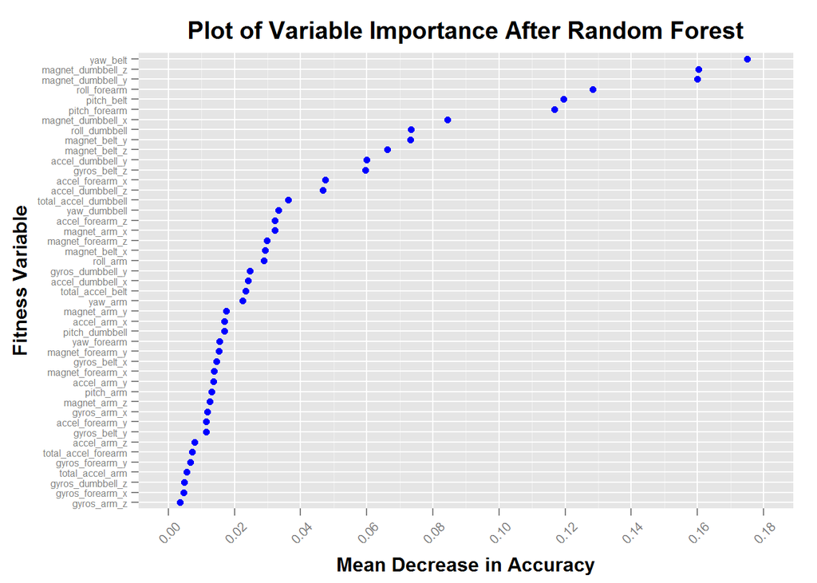

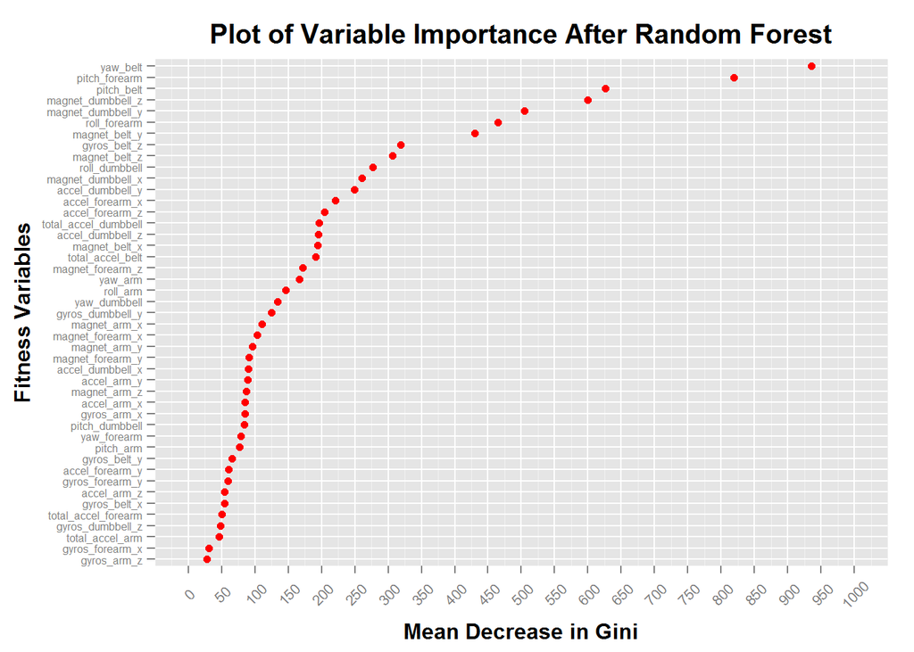

Both indicators give the same first variable (**yaw_belt**), and with the gini indicator the next variables are: **pitch_forearm**, **pitch_belt**, **magnet_dumbbell_z**, and **magnet_dumbbell_y**.

Let’s now check for OUT sample error using the test dataset:

```r
# Check predictions with testSet:
# Check predictions with testSet:
predictions <- predict(rf, testDta)
confusionMatrix(predictions, testDta$classe)
```

```
## Confusion Matrix and Statistics
##
##           Reference
## Prediction    A    B    C    D    E
##          A 2225   20    0    0    0
##          B    1 1496   14    0    0
##          C    3    2 1350   18    4
##          D    1    0    4 1267    2
##          E    2    0    0    1 1436
##
## Overall Statistics
##
##                Accuracy : 0.9908
##                  95% CI : (0.9885, 0.9928)
##     No Information Rate : 0.2845
##     P-Value [Acc > NIR] : < 2.2e-16
##
##                   Kappa : 0.9884
##  Mcnemar's Test P-Value : NA
##
## Statistics by Class:
##
##                      Class: A Class: B Class: C Class: D Class: E
## Sensitivity            0.9969   0.9855   0.9868   0.9852   0.9958
## Specificity            0.9964   0.9976   0.9958   0.9989   0.9995
## Pos Pred Value         0.9911   0.9901   0.9804   0.9945   0.9979
## Neg Pred Value         0.9988   0.9965   0.9972   0.9971   0.9991
## Prevalence             0.2845   0.1935   0.1744   0.1639   0.1838
## Detection Rate         0.2836   0.1907   0.1721   0.1615   0.1830
## Detection Prevalence   0.2861   0.1926   0.1755   0.1624   0.1834
## Balanced Accuracy      0.9967   0.9916   0.9913   0.9921   0.9977
```